# Opportunistic decision making and complexity in emergency care - ScienceDirect

## [Journal of Biomedical Informatics](https://www.sciencedirect.com/journal/journal-of-biomedical-informatics)

[Volume 44, Issue 3](https://www.sciencedirect.com/journal/journal-of-biomedical-informatics/vol/44/issue/3), June 2011, Pages 469-476

# Opportunistic decision making and complexity in emergency care

https://doi.org/10.1016/j.jbi.2011.04.001[Get rights and content](https://s100.copyright.com/AppDispatchServlet?publisherName=ELS&contentID=S1532046411000657&orderBeanReset=true)

Under an Elsevier [user license](http://www.elsevier.com/open-access/userlicense/1.0/)

open archive

## Abstract

In critical care environments such as the emergency department (ED), many activities and decisions are not planned. In this study, we developed a new methodology for systematically studying what are these unplanned activities and decisions. This methodology expands the traditional naturalistic decision making (NDM) frameworks by explicitly identifying the role of environmental factors in decision making. We focused on decisions made by ED physicians as they transitioned between tasks. Through ethnographic data collection, we developed a taxonomy of decision types. The empirical data provide important insight to the complexity of the ED environment by highlighting adaptive behavior in this intricate milieu. Our results show that half of decisions in the ED we studied are not planned, rather decisions are opportunistic decision (34%) or influenced by interruptions or distractions (21%). What impacts these unplanned decisions have on the quality, safety, and efficiency in the ED environment are important research topics for future investigation.

## Keywords

Opportunistic decision making

Opportunistic planning

Complexity

Emergency department

Methodology

Taxonomy of decision types

Across-task decisions

## 1. Introduction

Emergency departments (ED) in hospitals are complex environments that are high-workload, both information intensive and information poor, time sensitive, highly stressful, non-deterministic, interruption-laden, and life-critical. Optimal decision making, in these conditions, is difficult and sometimes impossible. As a result, physicians frequently make their decisions based on heuristics they have developed, opportunities that arise, or other external demands on their attention and activities. Effectively and efficiently managing cognitive, physical, spatial, and temporal resources in the ED environment is crucial for patient safety and quality of care.

In this paper, we begin with a description of our observations concerning the decisions made during task transitions in the ED. Next, we explain our taxonomy of decision types for task transitions based on the empirical study in the ED. Finally, we discuss the implications of task transition decision making by addressing the complexity issues for critical care in the context of patient safety, with a focus on opportunistic decision making.

The study of medical decision making is an increasingly influential area of research in biomedical informatics. Current theories of decision making from classical models of risk and utility to contextual models of naturalistic decision making (NDM) all emphasize the inherent factors of uncertainty and complexity in the medical decision process [1], [2]. Task complexity, including that created by uncertainty and non-linearity, affects the efficiency of decision-making, as more complex tasks require more cognitive effort [3], [4]. Decision support systems are one means of aiding and alleviating some of the difficulty [5]. However, much of the research on decision making and decision support systems has focused on the choices made during the care and treatment of a single patient. That is, these models revolve around a within-task choice in treatment or diagnostic reasoning. While this is a rich area for potential support with technology and a point in care with significant risk for error, physicians, particularly those in critical care environments such as emergency departments (EDs), also make many decisions *across* tasks (e.g. the selection of what to do next from multiple choices after finishing, or being interrupted on one task). These dynamic decisions (e.g., a series of decisions in real time [6]) during task transitions span a range of sub-goals, such as maintenance of situational awareness of the ED, concurrent care of multiple patients, and the training of medical students.

Our approach to decision making during task transitions is based on the distributed cognition perspective, which considers the ED as a distributed system composed of individuals and technology situated on complex physical, social, organizational environment extended across space and time [7], [8], [9]. This first study in our research program begins with the perspective of a single individual, the attending physician. We focus on how the environmental factors including interactions within the network of care providers and the artifacts in the ED affect what decisions are made. Building off previous research exploring naturalistic decision making from the impact of environmental factors on nursing triage decisions [10], cognitive schema in evidence based practice [11] and the effect of multitasking and interruptions on workflow [12], we focus here on decision types rather than generalized decision processes creating a broad perspective on critical care activities as well as a unique view of the complexity of an emergency department. Combining our novel method of categorizing physicians’ behaviors with a cognitive, ecologically based NDM [2] paradigm, we aim to create a framework capable of capturing the decisions made by the physicians as well as the environmental factors that contribute to these choices. Our goal is to create a taxonomy that elucidates the types of decisions made by physicians as they balance situational factors, system-wide decisions, and the care of individual patients. Such a classification system, highlighting the variability of the decisions made in complex medical environments, has important implications for critical care management and cognitive support for across-task decisions that are not covered by existing models of medical decision making.

## 2. Background and related studies

Traditional theories of decision making based on uncertainty, risk, and utility have been applied in medical domains [1], [13], [14]. Everything from formal decision analysis using standard decision trees [15] to computational methods [16] have been employed to represent problems and decisions in health care. While the goal of this paper is not to critique traditional versus contextual models of decision making (see Patel et al. [17] for such arguments), the decisions covered by the above theories characteristically focus on the selection of an optimal or rational choice from an array of possible choices within a given task. For example, Karni’s utility model [18] proposes that medical decision making “refers to the choice of a course of action following a diagnosis of a patient’s condition… where the objective of both parties [doctor and patient] is to choose the treatment that is best from the viewpoint of the patient’s welfare in all its relevant aspects.” Even Markov models designed to evaluate and simulate sequential decisions over time typically focus on specific clinical treatment problems such as the timing of a liver transplant [19], or the selection of a drug infusion plan [20].

Contextual or ecologically based paradigms of NDM are distinct from classical, normative models of decision theory in that NDM theories focus on decision making in *complex*, *natural* environments. NDM includes the influence of an individual’s knowledge and experience on their ability to assess complex (and uncertain) situations and to act on their knowledge in light of environmental factors [21]. However, while NDM recognizes that individuals’ decisions often deviate from the axioms of expected utility or probability theory [22], [23], NDM’s models of pattern recognition, analysis, simulation, and evaluation of scenarios and responses are also often studied within-task (e.g. anti-air warfare command and control officers [24]; behaviors by fireground commanders [25] , pilots [26] and nurses [27]).

Although studies of NDM in medicine [17], [28] have begun to shed light on the importance of viewing decision making as a complex, multi-layered *situated* process [11], [17], [28], there is a need to further develop methodologies that cover the full range of the medical decision making tasks including decisions during task transitions.

Therefore, to find the types of decisions made between tasks, we began by exploring the elements that influence behavior in the critical care environment of the emergency department. From there, we categorized the antecedents to events and their resulting decisions. By creating a taxonomy of decision types, we can explore the prevalence of these choices across physicians and environments (e.g. events during any shift) to consider generalizable patterns. We will conclude with a discussion of the implications of decision making across the boundaries of individual patient care.

## 3. Methodology

### 3.1. Forming a framework to categorize decision types

Naturalistic decision making research involves observing behaviors in the field and creating detailed descriptive accounts. Building on this methodology, we used a method combining an *a priori* classification framework with the provision of adding new categories discovered inductively in the data using Grounded Theory [35].

Decisions in the ED can be described at many levels of granularity. For example, X-raying a patient’s leg can be categorized at an abstract level as patient care, at a basic level of the decision as to the next step in assessment/diagnosis, or at a fine grain level (sub-ordinate) of the selection of imaging techniques (see Rosch [36], and Smith and Medin [37] for discussions on categorization). Therefore, it is necessary to specify at what level of detail efforts should be concentrated and analysis should occur. Using the multi-stage iterative method described in the Hybrid Method to Classify Interruptions and Activities (HyMCIA) developed by Brixey and colleagues [38], we adopted a flexible framework that allowed for categories to emerge both in data collection and analysis.

### 3.2. Data acquisition

Data was collected using shadowed observations. In shadowing a physician an observer records the details of the actions and interactions of the targeted individual. A convenience sample of five attending physicians were shadowed during their scheduled shifts. In the course of data collection, physicians were observed for four to 8 hours of each observed shift. Seven sessions across the five physicians totaling over 40 h of observation provided rich data for the analysis of workflow processes and decision making. During the shadowing sessions, environmental elements in the ED were recorded, including the actions and the locations of the activities by physicians, the time, the participants involved in the task (e.g. the other parties the physician might be speaking with, caring for, or interacting with), all observable antecedent events (e.g. being asked to attend to a patient, answer a call, responding to an alarm, etc.), and other ongoing events in the ED (e.g. arrival of new patients, consulting physicians from other departments appearing in the ED, number of beds filled, etc.). In addition to shadowed observation, our methods included a ‘think aloud’ narration of the physician’s activities [39]. However, given the demands of the ED, should a physician fail to provide this narrative no attempts were made to ask for clarification of the actions observed. To prevent any potential harm or alteration in the functioning of the ED, our observers did not interrupt or engage the physicians. Similarly, at a patient’s request, observers waited outside treatment rooms limiting data collection for infrequent spans of time.

All participants gave written informed consent prior to observation. Activities were recorded as they occurred and often included multiple activities within a single minute. The observers recorded observations in field note form. The level of granularity captured by the recording system along with the features of the field note form was developed over multiple iterations until a standard level of recording was obtained. In addition to the handwritten notes, an electronic form (UObserve) was developed on iPhone. This electronic form included aspects of the semi-structure field note form along with drop down menus capturing activities, participants, locations and free text comment space as well. This electronic field note format was developed and tested in conjunction with the handwritten notes. Upon further validation and reliability measures, this method may be deployed exclusively.

The observers typically worked in teams of groups of at least two. During the initial stages of project, all of the observers shadowed a single target physician. In the later stages of the second half of the study, each observer followed individual targets (i.e. attending physician, resident physician, and trauma nurse.) The group observations were used in developing the study protocol and as a means of training of new observers.

There were four observers for this study. Observer 1 is a master’s student in informatics as well as a trained MD. Observer 2 is a faculty member in the Center for Cognitive Informatics and Decision Making. She has over 10 years experience in qualitative observational methods but has no training as a health professional. Observer 3 is a graduate student in an informatics program with experience in human-factors psychology. Observer 4 is a Ph.D. student in informatics with training in computer science. Observer 4 created the iPhone application for the data collection. Each observer received training prior to data collection in the current protocol of observation and recording. During the actual data collection, the observers recorded their data independently and did not clarify observations (with each other or the physician) at that time. This independent data collection that was used to calculate inter-rater reliability for observations completed at a later time.

### 3.3. Data analysis

Following Grounded Theory, analysis of the data occurred concurrently with data collection and refinement in data collection protocols. The stages of data collection and analysis follow.

Shadowing protocol

- (1)

  At the start of each shift, the physicians to be shadowed (and other observed members of the ED personnel) gave informed consent.
- (2)

  Shadowed physicians were then followed, as permitted, throughout all activities in the trauma ED.
- (3)

  While detailed information was collected on the major activities of the shadowed physician, no recordings were made concerning the particular details of patient histories, patient treatments, and personal conversations.
- (4)

  Each observation session was recorded by hand and later converted in an excel file (see Fig. 1).

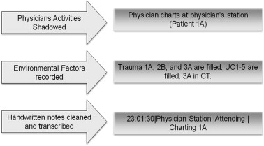

  1. [Download : Download full-size image](https://ars.els-cdn.com/content/image/1-s2.0-S1532046411000657-gr1.jpg)

  Fig. 1. The stages of data acquisition and processing.

Initially, the data collected was read and reread to gather a sense of the overall shift and gaps in the notes were noted [40], [41]. Over multiple-observations, the protocol for data collection became more refined as a standard for data collection was achieved. Multiple observers worked together comparing initial observations to determine the contextual factors needed to understand ED workflow (e.g. number of people in the waiting room, delays in imaging, etc.) post observation. From this comparison, a level of specification in detail was determined as being optimal for data collection (i.e. sparse enough level of detail to be captured by hand recording) and of sufficient quality for post observation recall (i.e. great enough detail for clarity). For example, a physician ordering a medication was an activity that was recorded, however, the drug, dosage, and directions for administration were not included in our field notes. Our data collection was centered at a basic level of categorization [42] that subsumed the details of many tasks (e.g. entering passcodes, calling up patient record, entering data into fields are all part of charting). Such details including information like the type of drug or its administration may be useful for a focused task analysis, however, concerning the decisions made across the care and management of an entire ED, a broader view of decision making is needed to depict more generalizable patterns in this initial study. In addition to selecting what aspects of a task were or were not included in our notes, a number of data fields also emerged as central parts of our recording system. For each observation, our team members recorded the time, location, the roles’ of participants in activity (e.g. attending physician and resident), known situational factors (e.g. number of patients needing triage), activities and the perceived goal of each action.

### 3.4. Data cleaning

Following field recording, each file was cleaned for consistency in the presentation of data elements and the data was transferred into Excel files (with cells for time, location, participants, activities, and antecedent events.), which were compared across observers with differences reconciled through discussion. For example, time stamps were used to determine the range of events. If multiple events were coded as a single observation by one observer and as separate occurrences by a second observer, a discussion ensued. Typically, this resulted in the observations being corrected to fit the multiple-observation format (see Fig. 2).

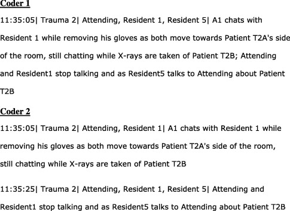

1. [Download : Download full-size image](https://ars.els-cdn.com/content/image/1-s2.0-S1532046411000657-gr2.jpg)

Fig. 2. Example of coding conflict concerning breaks between task transitions.

Clinical collaborators also provided insight as needed into understanding and describing the work processes observed. As our observations involved task transitions (e.g. shifting between patients, seeking information from others/computer records) limited understanding of medical procedures is required. A small number of data gaps were found (i.e. activities observed by only one coder (*n* = 13 of 285 observations used in final reliability assessment)). Once all transcribers agreed on the field notes, these notes were then analyzed for decisions types and environmental factors. Reliability was achieved, although disagreements in coding were kept as points for discussion and consideration.

## 4. Results

### 4.1. Decision types during task transitions

According to our distributed cognition framework for decision making, physician decisions in the ED are affected by a number of factors including cognitive (mental processing, cognitive capabilities, etc.), clinical (e.g., severity levels, diagnosis, etc.), physical (e.g., physical proximity, ED layout, etc.), organizational (division of labor, reporting structure, etc.), and human and equipment (personnel, patients, equipment, etc.) resources. Much of the prior work on workflow and decision making in the ED has focused on creating clinical pathways or elucidating naturalistic decisions in patient treatment. Our observations suggest a need to explore decision making at a different level. That is, what decisions do physicians make when selecting between pending goals? We analyzed the data to understand how these factors affect workflow through decisions during task transitions.

Based on our previous work [38], [43], we began with a list of canonical activities physicians complete in the ED. This includes common tasks such as patient assessment, observation, and communication. From our field notes, we analyzed these activities, the overarching goal for which each activity is conducted (e.g. care of patients, student teaching, etc.), the events surrounding each activity (e.g. patient arrival, X-rays complete), and the situational factors at that moment. Using these methods we determined that there are a number of task shifts in which a physician must select what their next action should be. The most obvious of these between tasks choices is the decision of *what to do following the completion of a goal*. As the chaos of the ED rarely allows a physician to see a task (such as caring of a single patient) through from beginning to end without a break, the selection of between – task actions moves physicians from one goal to the next without a necessary completion of task. These shifts between goals are areas of potential error.

In addition to decisions of what task to move onto following the completion of a goal, movement between the care of multiple patients is a type of between task decisions. That is in the goal of caring for patient 1, the care of patient 2 is a switch in task.

A number of categories of behaviors emerged from our data such as a deciding on the next goal, moving between patients, switching between roles (physician as care giver versus physician as teacher), and coping with environmentally forced breaks in task (interruptions, delays, and other disruptions). All of the aforementioned decisions are considered to be concerned with between task decisions (or goal selection). Using these decision spaces, we then consider what types of decisions are made in these moments.

**Three main types of decisions** emerged from our analyses. Physicians made *logical progression or planned decisions* as they actively selected their next action. Our iterative analysis quickly revealed that many activities follow a return to the logical progression of patient care after the completion of a different task. For example, although the attending physician may have seen other patients since the initial exam of the patient in Trauma Room 1, when the attending physician views the patient’s X-rays and he then decides to chart the findings, this is considered a planned choice (or logical progression) in treating this patient.

A second type of decision that emerged from the data is *opportunistic decisions*. These decisions are a choice in action created through unanticipated circumstances such as when moving between two tasks. For example, if a doctor stops to check on a patient sitting in the hall although he said in his think aloud protocol that he was moving to the CT room, we consider this stop along the way a decision of opportunity.

Similar unexpected choices or *breaks in task*, our third decision type, are sometimes forced upon a physician via an interruption or disruption. These breaks can be momentary such as the disruption of a pager going off (followed by a quick return to the previous activity) or an interruption by a nurse whose need requires an immediate change in task. Brixey et al. [38] and Hedberg et al. [32] have both discussed the impact of interruptions on work flow and decision making within critical care environments (see Fig. 3).

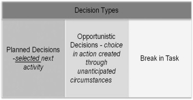

1. [Download : Download full-size image](https://ars.els-cdn.com/content/image/1-s2.0-S1532046411000657-gr3.jpg)

Fig. 3. Three types of observed decisions during task transitions.

Beyond identifying decisions types based on the intent of the physician (to select the next task = planned, respond to a break in task = disruption or interruption, or take advantage of an unexpected chance = opportunistic decision), we also must consider the role of the environmental elements or contextual factors that influence decisions. That is, what led to these decisions types.

### 4.2. Details of decision types

Further analysis of the details of our data led to the discovery that within each broad decision type, additional contextual influences could be identified. Planned decisions, which can follow the clinical pathway of treatment or the logical progression of care, can also be structured by the directions of a superior/colleague (e.g. an agreed upon course of action such as the order of completing hand offs during a shift changed). We therefore broadly define planned decisions as those in which an individual selects the next activity regardless of the source of impetus. These sources of influence can and do include:

- •

  Planned decisions
  - –

    **Protocol/logical** – next step in action series before the completion of a larger goal (e.g. following assessment there is creation of a treatment plan).
  - –

    **External forces** – external forces that shape the selection of activity. This is typically patient needs/status/priority or supervisor direction. This type of external force decision only occurs when the next activity is to be selected – otherwise an urgent patient need during an ongoing activity is coded as an interruption.
  - –

    **Preference** – individual selection of next activity when no other outside forces influence the selection of the decision. This is a habitual choice rather than a single decision that is likely to have some outside influence. (This could be a choice to physically walk around the department when load is low rather than updating situational awareness using Medhost as a proxy for walking the department (i.e. a ‘virtual’ walk around).

Similarly for breaks in task, the catalyst for the change in activities can derive from a number of sources. Physicians are often interrupted during a task by needs of others including nurses, students, and patients. On a number of occasions we have also observed physicians interrupting themselves. That is, the physician, either by action or through the think aloud protocol, projects one intended goal, but prior to reaching the necessary location, stops and redirects himself. Disruptions can also have a number of sources (devices such as phones, pagers, or alarms) that cause momentary breaks in task. However, unlike an interruption, a disruption does not involve a change in task. For example, in the course of taking a phone call a nurse may walk up to the physician. The doctor might hold up her index finger to indicate to the nurse to wait all without a break in speaking. We would consider the nurse’s approach as a disruption (although not an interruption as the physician’s task is continued to completion). Breaks in task are defined as seen below.

- •

  Break in task
  - –

    **Interruption** – occurs during ongoing activity and requires a shift in task.
    - •

      **By organizational design** – the physical layout of the workspace causes a break in work flow. For example, a physician may intend to check on patient in Trauma 1 and begin to walk to this treatment area, however, their progress is stymied because of chairs/beds/people blocking the area causing a shift to a new task.
    - •

      **By other/artifact** – an outside entity causes ongoing activity to be suspended and activity directed to another task (e.g. need to teach a student a procedure, need to provide information for nurse, etc.)
    - •

      **Self** – an individual, independent of another person, suspends an activity to perform another activity (e.g. interrupting charting to locate additional information, stopping as you walk down the hall because you think of something).
  - –

    **Disruption By Other/Artifact** – outside entity disrupts/overlaps with ongoing activity but this ongoing activity is not suspended (e.g. receiving a page but continuing with a procedure).

Finally, opportunistic decisions arise from the conflation of several unforeseen events. This includes a doctor being in the right place to complete an unexpected task, someone having additional resources available to them (such as unexpected personnel on the shift) or having a bit of free time when blocked from completing a task (e.g. waiting for an image to load.) Like opportunistic planning [33], in which individuals spontaneously take advantage of unforeseen opportunities to achieve their goals, **opportunistic decisions** are choices in action created through unanticipated circumstances.<sup>1</sup>

The three main sources of opportunity are proximity, time, and resources. While the above decision types are mutually exclusive, the antecedent or contextual factors need not be. It is possible to have the right person, the right time, and the right resources simultaneously to allow for a decision/activity that otherwise would not have occurred.

In general, opportunities arise from:

- •

  **Proximity** – use of physical location in decision-making. Nearness makes desirable this course of action. Proximity is an opportunistic decision but not all opportunistic decisions require proximity. For example, a doctor can select the next patient based on his or her proximity, but locate a piece of needed equipment when it is found unexpectedly on the doctor’s way to complete a different task.
- •

  **Time** – often generated by artifact absence, lulls in work load or during necessary delays (time during an X-ray). For instance, in caring for a patient, a physician must step away from the bedside while X-rays are being taken. If the physician uses these few minutes to check on the patient in the adjoining bed, this decision is considered to be based on an opportunity of time.
- •

  **Resources** – staff, materials, and other resources influencing decisions. For example, an additional attending physician during a shift may alter the distribution of demands (e.g. as you are available for that task, I can now do this other task.)

After determining the decision types (at both a general and contextually specific level), we coded our transcribed field notes by including a decision type with each action. The figure below shows the progression from the raw narrative form to the final data elements including time, location, participants, activities, and decision type. A second decision is included to demonstrate the transition.

## 5. Reliability (see Fig. 4)

Following the creation and use of this coding method, inter-rater reliability was calculated to assess the robustness of our classification system. All codings including disagreements were independently recorded and a group discussion assessed potential system as well as individual biases. Just as our data collection protocol was developed through iterative analysis, our decision classification system also underwent revision. In its final form, three independent researchers reached ‘substantial’ reliability (Cohen kappa = .61) on coding behaviors with these decision types. For example, the observed behavior ‘*Attending is at PACS (Nurse’s Station) reviewing CT image’* was coded by all three observers as a planned decision/logical progression. For comparison all coders agreed that ‘*Sees Resident 1 charting nearby, talks with Res1 about image then goes onto discuss second patient’* is an opportunistic decision of proximity.

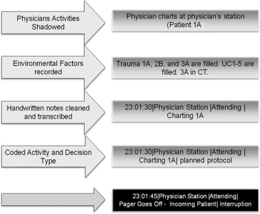

1. [Download : Download full-size image](https://ars.els-cdn.com/content/image/1-s2.0-S1532046411000657-gr4.jpg)

Fig. 4. The annotation and coding system for analyzing across-task decisions in ED.

After the completion of reliability measures, the remaining data was coded for decision type and the data was compared across sessions.

## 6. Decision types

The decision types for the seven sessions are displayed below in Fig. 5. Rather, that showing the variability within each of the broad decision categories, we focus on the higher-level decisions. The more specific decisions including environmental factors are situation-specific (e.g. the factors vary according to shift, physician, and patients). (For more discussion on the distribution of these elements across decisions see Liu [44].) Across seven attending physician shifts, clear patterns emerged where on average 45% (sd .14) of the physicians’ decisions were planned, 34% (sd .15) were opportunistic, and 21% (sd .6) were produced by a break in task*.*

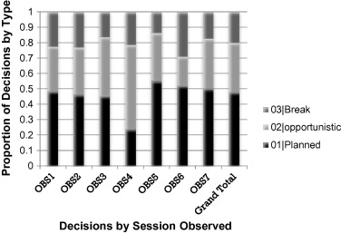

1. [Download : Download full-size image](https://ars.els-cdn.com/content/image/1-s2.0-S1532046411000657-gr5.jpg)

Fig. 5. Proportion of observed decisions by type from each observed sessions across multiple physicians.

It is only through the inclusion of decision types, rather than descriptive decision processes that we can see that the choices made in the ER are most often (55% opportunistic + break) created by the environment, rather than by conscious selection of the physician. That is contrary to expectation, task transition decisions are not in most cases guided by protocol but are instead the result of situational factors. Further, as these decisions are not based on choices in diagnostic reasoning, treatment options or other well established guidelines, this research highlights the need for new research on cognitive support at this level of decision making. For example, information display systems showing the current status of all the patients in the emergency room may help physicians to better select the next patient to care for based on patient need (rather than the physicians memory of who needed assessment or the patient’s proximity to the physician). Similar clinical dashboards have been developed for patient management in ICU care [45] and broader areas of resource allocation and project management. Our results suggest that work on the effect of opportunistic decision making on work flow is also needed. As opportunistic decisions account for one-third of the activity in the ED, it is important to determine if these choices maximize the efficiency of care or increase the complexity of an already chaotic environment.

In addition to physician data, two sessions observing the decisions of nurses were also analyzed. The nurse data was collected concurrently with the above physician data using identical methods. Like the physicians, the nurses had a large number of unplanned decisions, however, the proportion of planned decisions was higher for the nurses (56% and 63% respectively). Given this small quantity of data available and the variability between nurses, it is difficult to compare nurses decisions between tasks to physicians. Considering the differences in tasks, responsibilities and degree of independence in their work, physicians may respond more flexibly to their environment as reflected in non-deterministic decisions. Nurses, on the other hand, may have more direct contact with patients in procedural (i.e. planned) care. Such issues are being explored in current work.

## 7. Discussion

Our results indicate the need for refinements to NDM Models. While the generalized model of Bond and Cooper [30] and Klein [23] do not presuppose only within-task decisions, it might be useful to integrate environmental influences and across task considerations into the models. We propose a refinement of the NDM model below for our ED environment. At the highest level of the model is the maintenance of situational awareness of the ED as a whole. This can include recognition of patterns concerning the care of individual patients or broad influences (e.g. knowing bars closed 10 min ago, to the typical flow of ED traffic on rainy days). Our consulting physicians emphasized to our research team their desire to quickly create a treatment plan for each new patient in the ED as well as the maintenance of a plan for the running of the entire department. We would like to suggest that the consideration of goals includes a competition or at least awareness of multiple concurrent aims (e.g. treatment of patients, supervision of personnel, training of students.) Beyond this step of recognizing the conflict, recursive loops are needed to allow for the simulation of one goal’s actions, modification, and potential implementation and then another goal’s simulation steps as part of goal resolution. To ascertain variations in the mechanisms between models including dependence on heuristics or planning would require efforts beyond the scope of this paper. Similarly, future research is needed to explore the demands of concurrent of conflicting needs on cognitive planning. In the meantime, our current results suggest that clinicians are guided by their situational awareness. These findings suggest that the implementation of information displays (i.e. clinical dashboards) may allow physicians to better manage both immediate/intermediate goals as well as longer term planning through greater awareness of overall needs (see Fig. 6).

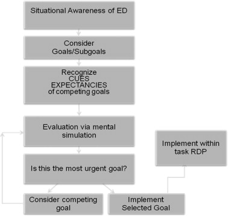

1. [Download : Download full-size image](https://ars.els-cdn.com/content/image/1-s2.0-S1532046411000657-gr6.jpg)

Fig. 6. Adaption of the model of Recognition-Primed decision making.

## 8. Conclusion

Our study has four implications for research on critical care complexity, medical decision making, and patient safety. First, our study focused on decision making during task transitions, which has important impact on workflow and ED complexity but has not received much attention in the traditional research on decision making. Second, we developed a new methodology for the study of decision making based on the distributed cognition framework that considers people and technology as an integrated system in complex physical, social, and organizational context. This methodology expanded the Recognition-Primed NDM framework by explicitly integrating a set of environment factors into decision making process and identifying their roles in decision making. Third, our study identified three major types of decisions during task transitions and this taxonomy is important in understanding how physicians make decisions in the ED and for developing decision support tools to improve decision making. Fourth, the empirical data provide important insight to the complexity or the chaotic nature of the ED environment. Our results show that half of decisions in the ED we studied are not planned, including 34% opportunistic decision making and 21% forced decisions by interruptions or distractions. How these unplanned decisions affect the quality, safety, and efficiency of care in the ED environment are important research topics that we are now investigating in our next phase of research.

## References

1. [1]

   L.R. Beach, R. Lipshitz

   Why classical decision theory is an inappropriate standard for evaluating and aiding most human decision making

   G.A. Klein, J. Oransanu, R. Calderwood, C.E. Zsambok (Eds.), Decision making in action: models and methods, Ablex Publishing, Norwood (1993), pp. 21-35

   Google Scholar
2. [2]

   G.A. Klein, J. Orasanu, R. Calderwood, C.E. Zsambok, G.A. Klein, J. Orasanu, *et al.*

   Decision making in action: models and methods

   Ablex, Norwood (1993)

   Google Scholar
3. [3]

   K. Bystrom, K. Jarvelin

   Task complexity affects information seeking and use

   Inform Process Manage, 31 (1995), pp. 191-213

   [View PDF](https://www.sciencedirect.com/science/article/pii/030645739580035R/pdf?md5=bb59b36635b8b560ce815d9d84eabd7b&pid=1-s2.0-030645739580035R-main.pdf)[View article](https://www.sciencedirect.com/science/article/pii/030645739580035R)[View in Scopus](https://www.scopus.com/inward/record.url?eid=2-s2.0-0029276227&partnerID=10&rel=R3.0.0)[Google Scholar](https://scholar.google.com/scholar_lookup?title=Task%20complexity%20affects%20information%20seeking%20and%20use&publication_year=1995&author=K.%20Bystrom&author=K.%20Jarvelin)
4. [4]

   V. Chinburapa, L.N. Larson, M. Brucks, J.L. Draugalis, J.L. Bootman, C.P. Puto

   Physician prescribing decisions: the effects of situational involvement and task complexity on information acquisition and decision making

   Soc Sci Med, 36 (1993), pp. 1473-1482

   [View PDF](https://www.sciencedirect.com/science/article/pii/027795369390389L/pdf?md5=ff68d5257fc20bf214aebe37726ae89f&pid=1-s2.0-027795369390389L-main.pdf)[View article](https://www.sciencedirect.com/science/article/pii/027795369390389L)[View in Scopus](https://www.scopus.com/inward/record.url?eid=2-s2.0-0027256122&partnerID=10&rel=R3.0.0)Google Scholar
5. [5]

   R.E. Wood

   Task complexity: definition of the construct

   Organ Behav Hum Dec Process, 37 (1986), pp. 60-82

   [View PDF](https://www.sciencedirect.com/science/article/pii/0749597886900440/pdf?md5=1835b6ea0c19c33592806143e4945aa0&pid=1-s2.0-0749597886900440-main.pdf)[View article](https://www.sciencedirect.com/science/article/pii/0749597886900440)[View in Scopus](https://www.scopus.com/inward/record.url?eid=2-s2.0-0002853668&partnerID=10&rel=R3.0.0)[Google Scholar](https://scholar.google.com/scholar_lookup?title=Task%20complexity%3A%20definition%20of%20the%20construct&publication_year=1986&author=R.E.%20Wood)
6. [6]

   B. Brehmer

   Dynamic decision making: human control of complex systems

   Acta Psychol, 81 (1992), pp. 211-241

   [View PDF](https://www.sciencedirect.com/science/article/pii/000169189290019A/pdf?md5=743c5d6eb0541ffcd79a875fdc76de3b&pid=1-s2.0-000169189290019A-main.pdf)[View article](https://www.sciencedirect.com/science/article/pii/000169189290019A)[View in Scopus](https://www.scopus.com/inward/record.url?eid=2-s2.0-0027024489&partnerID=10&rel=R3.0.0)[Google Scholar](https://scholar.google.com/scholar_lookup?title=Dynamic%20decision%20making%3A%20human%20control%20of%20complex%20systems&publication_year=1992&author=B.%20Brehmer)
7. [7]

   S.M. Rinkus, M. Walji, K.A. Johnson, J. Malin, J.P. Turley, J.W. Smith, *et al.*

   Human-centered design of a distributed knowledge management system

   J Biomed Inform, 38 (2005), pp. 4-17

   [View PDF](https://www.sciencedirect.com/science/article/pii/S153204640400156X/pdfft?md5=385ff49c791d74e0b200160bc17a7054&pid=1-s2.0-S153204640400156X-main.pdf)[View article](https://www.sciencedirect.com/science/article/pii/S153204640400156X)[View in Scopus](https://www.scopus.com/inward/record.url?eid=2-s2.0-13444273277&partnerID=10&rel=R3.0.0)Google Scholar
8. [8]

   J. Zhang, V.L. Patel, K.A. Johnson, J. Malin, J.W. Smith

   Designing human-centered distributed information systems

   IEEE Intell Syst, 17 (2002), pp. 42-47

   Google Scholar
9. [9]

   V.L. Patel, J. Zhang, N.A. Yoskowitz, R. Green, O.R. Sayan

   Translational cognition for decision support in critical care environments: a review

   J Biomed Inform, 41 (2008), pp. 413-431

   [View PDF](https://www.sciencedirect.com/science/article/pii/S1532046408000166/pdfft?md5=c1c892ea23d688ff2e364170d250da5e&pid=1-s2.0-S1532046408000166-main.pdf)[View article](https://www.sciencedirect.com/science/article/pii/S1532046408000166)[View in Scopus](https://www.scopus.com/inward/record.url?eid=2-s2.0-44649142577&partnerID=10&rel=R3.0.0)Google Scholar
10. [10]

    A. Andersson, M. Omberg, M. Svelund

    Triage in the emergency department – a qualitative study of the factors which nurses consider when making decisions

    Nurs Crit Care, 11 (2006), pp. 136-145

    [CrossRef](https://doi.org/10.1111/j.1362-1017.2006.00162.x)[View in Scopus](https://www.scopus.com/inward/record.url?eid=2-s2.0-33745253731&partnerID=10&rel=R3.0.0)Google Scholar
11. [11]

    P. Falzer

    Cognitive schema and naturalistic decision making in evidence-based practices

    J Biomed Inform, 37 (2004), pp. 86-98

    [View PDF](https://www.sciencedirect.com/science/article/pii/S153204640400022X/pdfft?md5=267ae8a9670febd7d6f8deef882514e8&pid=1-s2.0-S153204640400022X-main.pdf)[View article](https://www.sciencedirect.com/science/article/pii/S153204640400022X)[View in Scopus](https://www.scopus.com/inward/record.url?eid=2-s2.0-2342646188&partnerID=10&rel=R3.0.0)[Google Scholar](https://scholar.google.com/scholar_lookup?title=Cognitive%20schema%20and%20naturalistic%20decision%20making%20in%20evidence-based%20practices&publication_year=2004&author=P.%20Falzer)
12. [12]

    A. Laxmisan, F. Hakimzada, O. Sayan, R. Green, J. Zhang, V. Patel

    The multitasking clinician: decision-making and cognitive demand during and after team handoffs in emergency care

    Int J Med Inform, 76 (2007), pp. 801-811

    [View PDF](https://www.sciencedirect.com/science/article/pii/S1386505606002413/pdfft?md5=3ec47fe41ed7ab5119846a8dd80040ae&pid=1-s2.0-S1386505606002413-main.pdf)[View article](https://www.sciencedirect.com/science/article/pii/S1386505606002413)[View in Scopus](https://www.scopus.com/inward/record.url?eid=2-s2.0-33947232046&partnerID=10&rel=R3.0.0)Google Scholar
13. [13]

    A.S. Elstein, D.R. Rovner, G.B. Holzman, M.M. Ravitch, M.L. Rothert, M.M. Holmes

    Psychological approaches to medical decision making

    Am Behav Sci, 25 (1982), pp. 557-584

    [CrossRef](https://doi.org/10.1177/000276482025005007)[View in Scopus](https://www.scopus.com/inward/record.url?eid=2-s2.0-84970442232&partnerID=10&rel=R3.0.0)Google Scholar
14. [14]

    A.S. Elstein

    Naturalistic decision making and clinical judgement

    J Behav Decis Making, 14 (2001), pp. 353-384

    [Google Scholar](https://scholar.google.com/scholar_lookup?title=Naturalistic%20decision%20making%20and%20clinical%20judgement&publication_year=2001&author=A.S.%20Elstein)
15. [15]

    Roberts MS. Markov process-based Monte Carlo simulation: a tool for modeling complex disease and its application to the timing of liver transplantation. In: Proceedings of the 24th conference on winter simulation; 1992. p. 1034–40.

    Google Scholar
16. [16]

    J.R. Beck, S.G. Pauker

    The Markov process in medical prognosis

    Med Decis Making, 3 (1983), pp. 419-458

    [View in Scopus](https://www.scopus.com/inward/record.url?eid=2-s2.0-0021021373&partnerID=10&rel=R3.0.0)[Google Scholar](https://scholar.google.com/scholar_lookup?title=The%20Markov%20process%20in%20medical%20prognosis&publication_year=1983&author=J.R.%20Beck&author=S.G.%20Pauker)
17. [17]

    V.L. Patel, D.R. Kaufman, J.F. Arocha

    Emerging paradigms of cognition in medical decision-making

    J Biomed Inform, 35 (2002), pp. 52-75

    [View PDF](https://www.sciencedirect.com/science/article/pii/S1532046402000096/pdfft?md5=9773822d97b12d70f4a96c103a07c8c4&pid=1-s2.0-S1532046402000096-main.pdf)[View article](https://www.sciencedirect.com/science/article/pii/S1532046402000096)[View in Scopus](https://www.scopus.com/inward/record.url?eid=2-s2.0-0036402705&partnerID=10&rel=R3.0.0)[Google Scholar](https://scholar.google.com/scholar_lookup?title=Emerging%20paradigms%20of%20cognition%20in%20medical%20decision-making&publication_year=2002&author=V.L.%20Patel&author=D.R.%20Kaufman&author=J.F.%20Arocha)
18. [18]

    E. Karni

    A theory of medical decision making under uncertainty

    J Risk Uncertainty, 39 (2009), pp. 1-16

    [CrossRef](https://doi.org/10.1007/s11166-009-9071-3)[View in Scopus](https://www.scopus.com/inward/record.url?eid=2-s2.0-67549117185&partnerID=10&rel=R3.0.0)[Google Scholar](https://scholar.google.com/scholar_lookup?title=A%20theory%20of%20medical%20decision%20making%20under%20uncertainty&publication_year=2009&author=E.%20Karni)
19. [19]

    O. Alagoz, H. Hsu, A.J. Schaefer, M.S. Roberts

    Markov decision processes: a tool for sequential decision making under uncertainty

    Med Decis Making, 30 (2009), pp. 474-483

    Google Scholar
20. [20]

    C. Hu, W.S. Lovejoy, S.L. Shafer

    Comparison of some suboptimal control policies in medical drug therapy

    Oper Res, 44 (1996), pp. 696-709

    [CrossRef](https://doi.org/10.1287/opre.44.5.696)Google Scholar
21. [21]

    G. Klein

    An overview of naturalistic decision making applications

    C. Zsambok (Ed.), Naturalistic decision making, Lawrence Erlbaum Associates Publishers, Mahwah (1997), pp. 49-59

    [Google Scholar](https://scholar.google.com/scholar_lookup?title=An%20overview%20of%20naturalistic%20decision%20making%20applications&publication_year=1997&author=G.%20Klein)
22. [22]

    D. Kahneman, P. Slavic, A. Tversky

    Judgment under uncertainty: heuristics and biases

    Cambridge University Press, New York (1982)

    [Google Scholar](https://scholar.google.com/scholar_lookup?title=Judgment%20under%20uncertainty%3A%20heuristics%20and%20biases&publication_year=1982&author=D.%20Kahneman&author=P.%20Slavic&author=A.%20Tversky)
23. [23]

    G.A. Klein

    Naturalistic decision making

    Hum Factors: J Hum Fact Ergon Soc, 50 (2008), pp. 456-460

    [View in Scopus](https://www.scopus.com/inward/record.url?eid=2-s2.0-47749150648&partnerID=10&rel=R3.0.0)[Google Scholar](https://scholar.google.com/scholar_lookup?title=Naturalistic%20decision%20making&publication_year=2008&author=G.A.%20Klein)
24. [24]

    G.L. Kaempf, G.A. Klein, M.L. Thordsen, S. Wolf

    Decision making in complex command-and-control environments

    Hum Fact: J Hum Fact Ergon Soc, 38 (1996), pp. 220-231

    [View in Scopus](https://www.scopus.com/inward/record.url?eid=2-s2.0-0030175010&partnerID=10&rel=R3.0.0)Google Scholar
25. [25]

    G.A. Klein, R. Calderwood, D. MacGregor

    Critical decision method for eliciting knowledge

    Syst, Man Cybern IEEE Trans, 19 (1989), pp. 462-472

    [Google Scholar](https://scholar.google.com/scholar_lookup?title=Critical%20decision%20method%20for%20eliciting%20knowledge&publication_year=1989&author=G.A.%20Klein&author=R.%20Calderwood&author=D.%20MacGregor)
26. [26]

    J. Orasanu, U. Fischer

    Finding decisions in natural environments: the view from the cockpit

    C.E. Zsambok, G.A. Klein (Eds.), Naturalistic decision making, Lawerence Erlbaum, Mahwah (1997)

    [Google Scholar](https://scholar.google.com/scholar_lookup?title=Finding%20decisions%20in%20natural%20environments%3A%20the%20view%20from%20the%20cockpit&publication_year=1997&author=J.%20Orasanu&author=U.%20Fischer)
27. [27]

    J.M. Randel, H.L. Pugh, S.K. Reed

    Methods for analyzing cognitive skills for a technical task

    Int J Hum Comput Stud, 45 (1996), pp. 579-597

    [View PDF](https://www.sciencedirect.com/science/article/pii/S1071581996900683/pdf?md5=5589bf6dfd3fb7d03b19aace1a75d7ad&pid=1-s2.0-S1071581996900683-main.pdf)[View article](https://www.sciencedirect.com/science/article/pii/S1071581996900683)[View in Scopus](https://www.scopus.com/inward/record.url?eid=2-s2.0-0030291543&partnerID=10&rel=R3.0.0)[Google Scholar](https://scholar.google.com/scholar_lookup?title=Methods%20for%20analyzing%20cognitive%20skills%20for%20a%20technical%20task&publication_year=1996&author=J.M.%20Randel&author=H.L.%20Pugh&author=S.K.%20Reed)
28. [28]

    C. Chisholm, E. Collison, D. Nelson, *et al.*

    Emergency department workplace interruptions: are emergency physicians “interrupt-driven” and “multitaking”?

    Acad Emerg Med, 7 (2000), pp. 1239-1243

    [CrossRef](https://doi.org/10.1111/j.1553-2712.2000.tb00469.x)[View in Scopus](https://www.scopus.com/inward/record.url?eid=2-s2.0-0033757786&partnerID=10&rel=R3.0.0)Google Scholar
29. [29]

    C.E. Zsambok

    Naturalistic decision making: where are we now?

    C.E. Zsambok, G.A. Klein (Eds.), Naturalistic decision making, Lawerence Erlbaum, Mahwah (1997)

    [Google Scholar](https://scholar.google.com/scholar_lookup?title=Naturalistic%20decision%20making%3A%20where%20are%20we%20now&publication_year=1997&author=C.E.%20Zsambok)
30. [30]

    S. Bond, S. Cooper

    Modelling emergency decisions: recognition-primed decision making. The literature in relation to an ophthalmic critical incident

    J Clin Nurs, 15 (2006), pp. 1023-1032

    [CrossRef](https://doi.org/10.1111/j.1365-2702.2006.01399.x)[View in Scopus](https://www.scopus.com/inward/record.url?eid=2-s2.0-33745905289&partnerID=10&rel=R3.0.0)Google Scholar
31. [31]

    G.A. Klein

    A recognition-primed decision (RPD) model of rapid decision making

    G.A. Klein, J. Orasanu, R. Calderwood, C.E. Zsambok (Eds.), Decision making in action: models and methods, Ablex, Norwood (1993), pp. 138-147

    [Google Scholar](https://scholar.google.com/scholar_lookup?title=A%20recognition-primed%20decision%20%20model%20of%20rapid%20decision%20making&publication_year=1993&author=G.A.%20Klein)
32. [32]

    B. Hedberg, U.S. Larson

    Environmental elements affecting the decision making process in nursing practice

    J Clin Nurs, 13 (2004), pp. 316-324

    [CrossRef](https://doi.org/10.1046/j.1365-2702.2003.00879.x)[View in Scopus](https://www.scopus.com/inward/record.url?eid=2-s2.0-0942263839&partnerID=10&rel=R3.0.0)Google Scholar
33. [33]

    B. Hayes-Roth, F. Hayes-Roth

    A cognitive model of planning

    Cognitive Sci, 3 (1979), pp. 275-310

    [View PDF](https://www.sciencedirect.com/science/article/pii/S0364021379800105/pdf?md5=9a9d9693c70de262ff357a95e3e3dd78&pid=1-s2.0-S0364021379800105-main.pdf)[View article](https://www.sciencedirect.com/science/article/pii/S0364021379800105)[View in Scopus](https://www.scopus.com/inward/record.url?eid=2-s2.0-0018594651&partnerID=10&rel=R3.0.0)[Google Scholar](https://scholar.google.com/scholar_lookup?title=A%20cognitive%20model%20of%20planning&publication_year=1979&author=B.%20Hayes-Roth&author=F.%20Hayes-Roth)
34. [34]

    R. Wears, S. Perry

    Human factors and ergonomics in the emergency department

    Ann Emerg Med, 40 (2002), pp. 206-212

    [View PDF](https://www.sciencedirect.com/science/article/pii/S0196064402000306/pdfft?md5=4ea5a1075e4e2b60b81bd018279819f1&pid=1-s2.0-S0196064402000306-main.pdf)[View article](https://www.sciencedirect.com/science/article/pii/S0196064402000306)[View in Scopus](https://www.scopus.com/inward/record.url?eid=2-s2.0-0036311577&partnerID=10&rel=R3.0.0)[Google Scholar](https://scholar.google.com/scholar_lookup?title=Human%20factors%20and%20ergonomics%20in%20the%20emergency%20department&publication_year=2002&author=R.%20Wears&author=S.%20Perry)
35. [35]

    B. Glaser, A. Strauss

    The discovery of grounded theory

    Aldine Publishing, New York (1967)

    [Google Scholar](https://scholar.google.com/scholar_lookup?title=The%20discovery%20of%20grounded%20theory&publication_year=1967&author=B.%20Glaser&author=A.%20Strauss)
36. [36]

    E. Rosch

    Principles of categorization

    E. Rosch, B. Lloyd (Eds.), Cognition and categorization, Erlbaum, Hillsdale (1978)

    [Google Scholar](https://scholar.google.com/scholar_lookup?title=Principles%20of%20categorization&publication_year=1978&author=E.%20Rosch)
37. [37]

    E. Smith, D. Medin

    Categories and concepts

    Harvard University Press, Cambridge (1981)

    [Google Scholar](https://scholar.google.com/scholar_lookup?title=Categories%20and%20concepts&publication_year=1981&author=E.%20Smith&author=D.%20Medin)
38. [38]

    J.J. Brixey, D.J. Robinson, C.W. Johnson, T.R. Johnson, J.P. Turley, V.L. Patel, *et al.*

    Towards a hybrid method to categorize interruptions and activities in healthcare

    Int J Med Inform, 76 (2006), pp. 812-820

    Google Scholar
39. [39]

    A. Newall, H.A. Simon

    Human problem solving

    Prentice-Hall, Englewood Cliffs (1972)

    [Google Scholar](https://scholar.google.com/scholar_lookup?title=Human%20problem%20solving&publication_year=1972&author=A.%20Newall&author=H.A.%20Simon)
40. [40]

    D. Silverman

    Qualitative research: theory, method and practice

    SAGE Publications, London (1997)

    [Google Scholar](https://scholar.google.com/scholar_lookup?title=Qualitative%20research%3A%20theory%2C%20method%20and%20practice&publication_year=1997&author=D.%20Silverman)
41. [41]

    D. Polit, B. Hungler

    Nursing research principles and methods

    J.B. Lippincott Company, Philadelphia (1997)

    [Google Scholar](https://scholar.google.com/scholar_lookup?title=Nursing%20research%20principles%20and%20methods&publication_year=1997&author=D.%20Polit&author=B.%20Hungler)
42. [42]

    E.H. Rosch, C.B. Mervis, D.M. Johnson, P. Bayes Braem

    Basic objects in natural categories

    Cognitive Psychol, 8 (1976), pp. 382-439

    [View PDF](https://www.sciencedirect.com/science/article/pii/001002857690013X/pdf?md5=b0d51097a663097d344ea9bf65a4f427&pid=1-s2.0-001002857690013X-main.pdf)[View article](https://www.sciencedirect.com/science/article/pii/001002857690013X)[View in Scopus](https://www.scopus.com/inward/record.url?eid=2-s2.0-34248936100&partnerID=10&rel=R3.0.0)[Google Scholar](https://scholar.google.com/scholar_lookup?title=Basic%20objects%20in%20natural%20categories&publication_year=1976&author=E.H.%20Rosch&author=C.B.%20Mervis&author=D.M.%20Johnson&author=P.%20Bayes%20Braem)
43. [43]

    J. Zhang, V.L. Patel, T.R. Johnson, E.H. Shortliffe

    A cognitive taxonomy of medical errors

    J Biomed Inform, 37 (2004), pp. 193-204

    [View PDF](https://www.sciencedirect.com/science/article/pii/S1532046404000528/pdfft?md5=5b22382bac6acac90dacefd257053c1d&pid=1-s2.0-S1532046404000528-main.pdf)[View article](https://www.sciencedirect.com/science/article/pii/S1532046404000528)[View in Scopus](https://www.scopus.com/inward/record.url?eid=2-s2.0-2942601198&partnerID=10&rel=R3.0.0)[Google Scholar](https://scholar.google.com/scholar_lookup?title=A%20cognitive%20taxonomy%20of%20medical%20errors&publication_year=2004&author=J.%20Zhang&author=V.L.%20Patel&author=T.R.%20Johnson&author=E.H.%20Shortliffe)
44. [44]

    Liu Y. The impact of environmental factors on physician decision making in emergency department. Master’s Thesis, unpublished, University of Texas HSCH; 2010.

    Google Scholar
45. [45]

    M. Egan

    Clinical dashboards: impact on workflow, care quality, and patient safety

    Crit Care Nurs Quart, 29 (2006), pp. 354-361

    [CrossRef](https://doi.org/10.1097/00002727-200610000-00008)[View in Scopus](https://www.scopus.com/inward/record.url?eid=2-s2.0-33750603411&partnerID=10&rel=R3.0.0)[Google Scholar](https://scholar.google.com/scholar_lookup?title=Clinical%20dashboards%3A%20impact%20on%20workflow%2C%20care%20quality%2C%20and%20patient%20safety&publication_year=2006&author=M.%20Egan)

- 2020, Journal of Biomedical Informatics

- 2020, Journal of Emergency Medicine

- 2020, Annals of Emergency Medicine

- 2019, International Journal of Information Management

- 2023, Research Square

**<sup>1</sup>**

Opportunistic planning is limited to the reordering of priorities or strategies in achieving goals to take advantage of circumstance. Opportunistic decision making is a broader concept extending to can the creation and completion of new tasks outside of any prior plan of action triggered by a congruence of unforeseen events.

Copyright © 2011 Elsevier Inc. All rights reserved.

Edited by Vimla L. Patel, Thomas G. Kannampallil

[View special issue](https://www.sciencedirect.com/science/journal/15320464/vsi/103M2K6RJGZ)